# Archaic Ancestry

Sarah Johnson

2025-09-16

In this notebook, I will analyze jointly all of the archaic ancestry of worldwide populations. I’m really focused here on Denisovan, but will also use Neanderthal to make sure that things are consistent with other publications.

First I want to compare my results to Laurits’ from the Lasi-dad supplement. Using his annotations, I recover slightly less but never more than 1Mb less. When I use my own annotations again I recover slightly less. I believe this is because I use positions that pass the combined archaic mask.

Using my method, I recover on average 5% less of Denisovan ancestry and 2% less of Neanderthal. I’m not worried by this, and am mostly happy that the numbers are consistent. My method is clearly working!!!

```r
LS <- read.table("summary_dat/hmmix/LASIDAD_supp6.txt", sep = "\t", header = T)
LS$Segment.type <- ifelse(LS$Segment.type == "none", "None", LS$Segment.type)

LASI_class1LS_comp <- class1LS %>% group_by(ID, population, class_1, dataset) %>%
  summarize(amount = sum(amount)) %>%
  ungroup %>%
  group_by(population, class_1, dataset) %>%
  summarize(avg = round(mean(amount) / 1000000, 1)) %>%
  filter(dataset == "LASI") %>%
  rename("Segment.type" = class_1, "Region" = population) %>%
  merge(filter(LS, class == "class1", dataset == "LASIDAD"), by = c("Segment.type", "Region"))
```

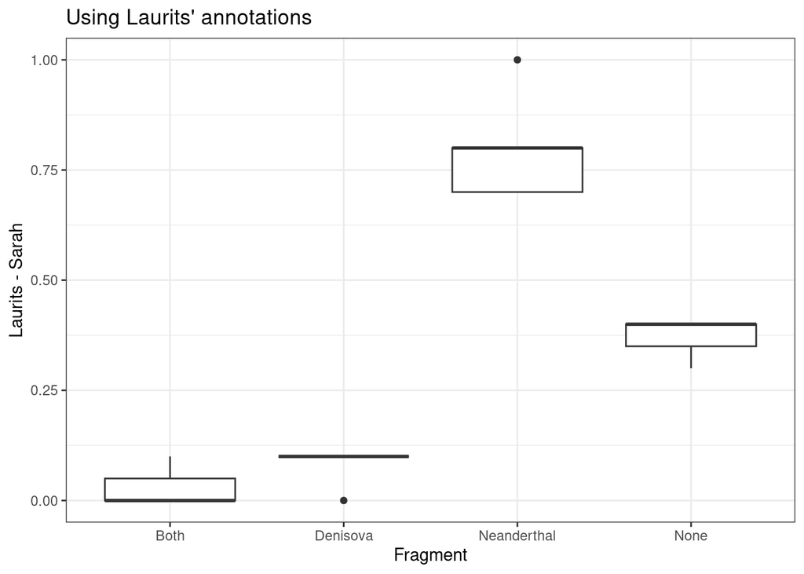

```r
p_LS <- ggplot(LASI_class1LS_comp, aes(x = Segment.type, y = (X0.8 - avg))) +
  geom_boxplot() +
  theme_bw() +
  labs(x = "Fragment", y = "Laurits - Sarah", title = "Using Laurits' annotations")
plot(p_LS)
```

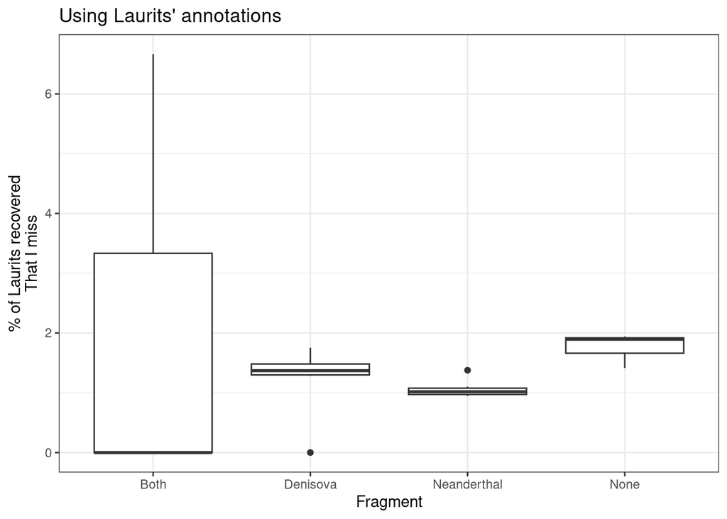

```r
p_LS_per <- ggplot(LASI_class1LS_comp, aes(x = Segment.type, y = (X0.8 - avg) / X0.8 * 100)) +
  geom_boxplot() +
  theme_bw() +
  labs(x = "Fragment", y = "% of Laurits recovered\nThat I miss", title = "Using Laurits' annotations")
plot(p_LS_per)
```

```r
LASI_class1_comp <- class1 %>% group_by(ID, population, class_1, dataset) %>%
  summarize(amount = sum(amount)) %>%
  ungroup %>%
  group_by(population, class_1, dataset) %>%
  summarize(avg = round(mean(amount) / 1000000, 1)) %>%
  filter(dataset == "LASI") %>%
  rename("Segment.type" = class_1, "Region" = population) %>%
  merge(filter(LS, class == "class1", dataset == "LASIDAD"), by = c("Segment.type", "Region"))
```

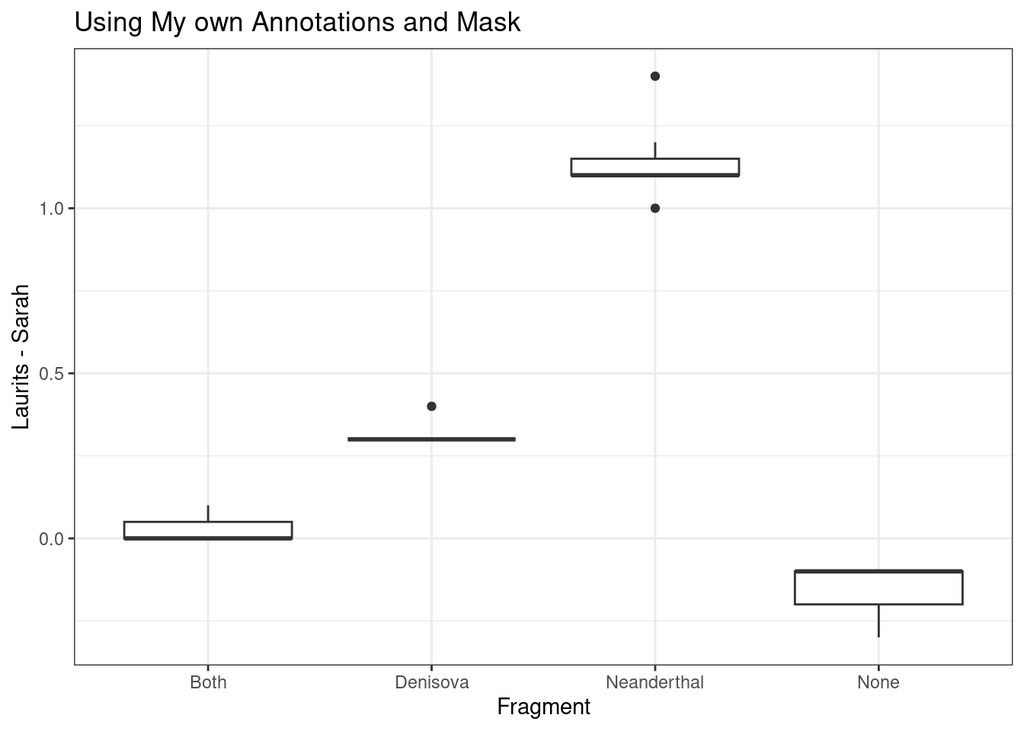

```r
p_c1 <- ggplot(LASI_class1_comp, aes(x = Segment.type, y = (X0.8 - avg))) +
  geom_boxplot() +
  theme_bw() +
  labs(x = "Fragment", y = "Laurits - Sarah", title = "Using My own Annotations and Mask")
plot(p_c1)
```

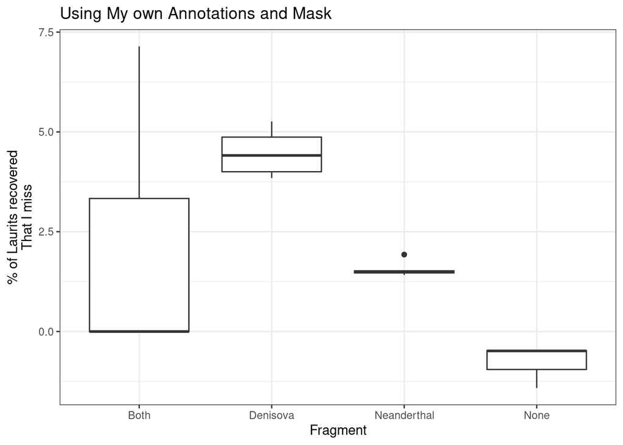

```r
p_c1_per <- ggplot(LASI_class1_comp, aes(x = Segment.type, y = (X0.8 - avg) / X0.8 * 100)) +
  geom_boxplot() +
  theme_bw() +
  labs(x = "Fragment", y = "% of Laurits recovered\nThat I miss", title = "Using My own Annotations and Mask")
plot(p_c1_per)
```

Also look at worldwide populations

```r
WW_class1LS_comp <- class1LS %>% filter(dataset != "LASI") %>%
  group_by(population, class_1, dataset, Region, ID) %>%
  summarize(amount = sum(amount)) %>%
  ungroup() %>%
  group_by(class_1, Region) %>%
  summarize(avg = mean(amount) / 1000000, sd = sd(amount) / 1000000)  %>%
  rename("Segment.type" = class_1) %>%
  merge(filter(LS, class == "class1", dataset == "WW"), by = c("Segment.type", "Region"))
```

```
## 'Region'. You can override using the `.groups` argument.
```

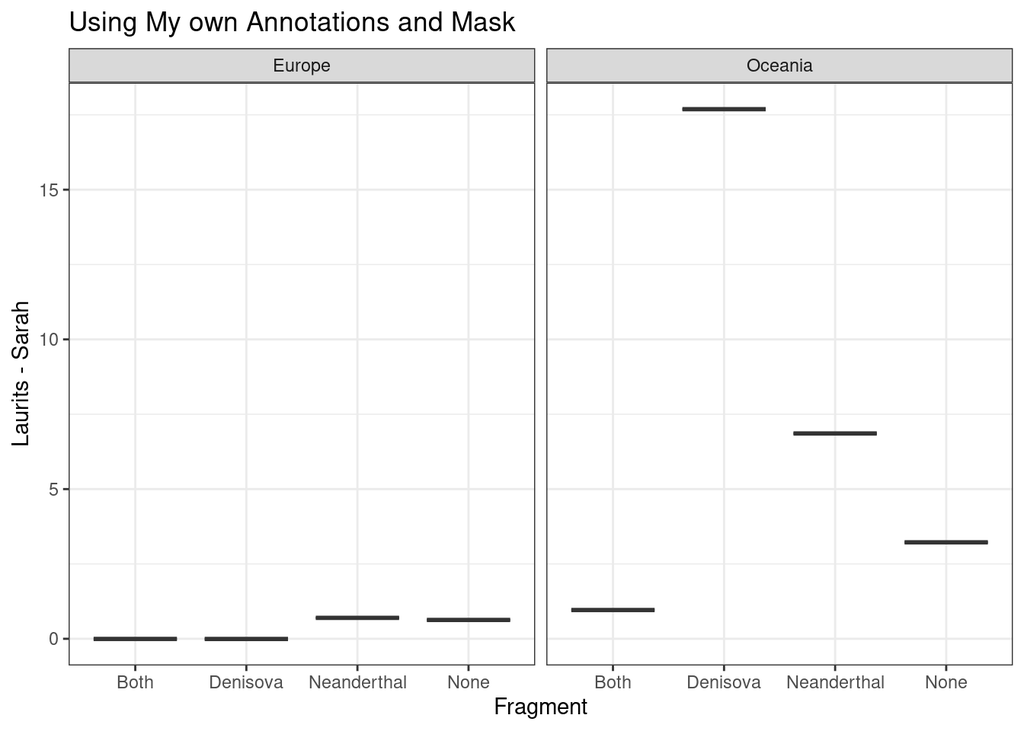

```r
p_c1 <- ggplot(WW_class1LS_comp, aes(x = Segment.type, y = (X0.8 - avg))) +
  geom_boxplot() +
  theme_bw() +
  labs(x = "Fragment", y = "Laurits - Sarah", title = "Using My own Annotations and Mask") +
  facet_wrap(~Region)
plot(p_c1)
```

Now I want to look at how much Denisovan per individual

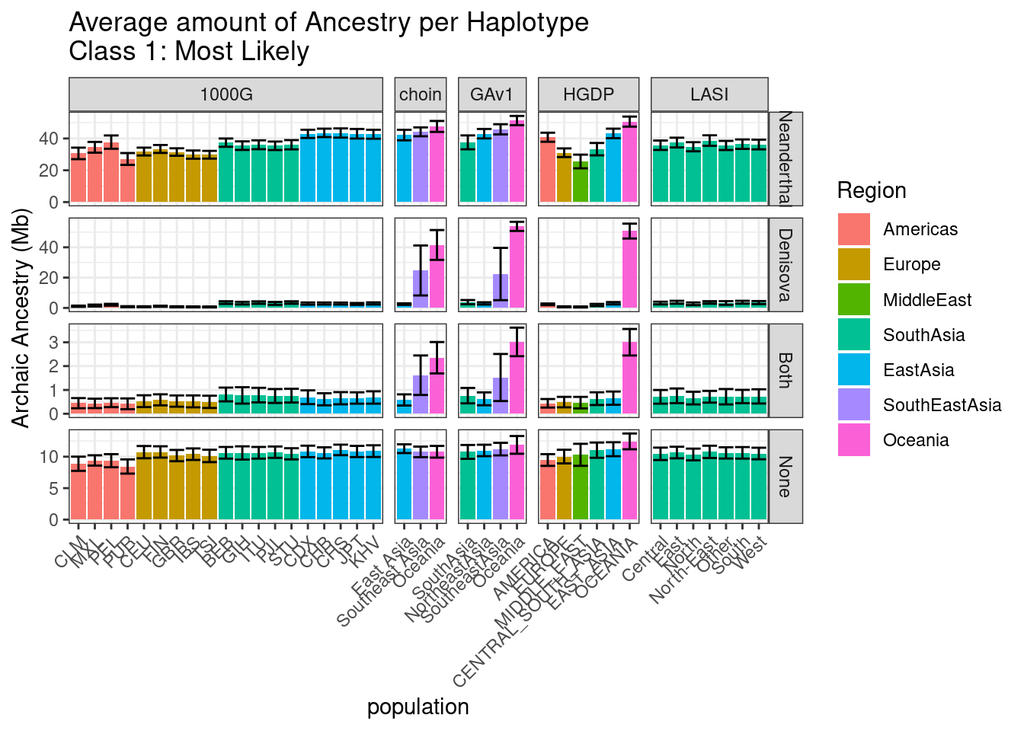

```r
# Ensure Region has a defined order
class1$Region <- factor(class1$Region, levels = c("Americas", "Europe", "MiddleEast", "SouthAsia", "EastAsia", "SouthEastAsia", "Oceania"))

# Arrange populations by Region and then convert to factor
pop_levels <- class1 %>%
  distinct(population, Region) %>%
  arrange(Region, population) %>%
  pull(population)
class1$population <- factor(class1$population, levels = pop_levels)

# finally order the classifications
class1$class_1 <- factor(class1$class_1, levels = c("Neanderthal", "Denisova", "Both", "None"), ordered = T)

p_hap <- class1 %>% group_by(population, class_1, dataset, Region) %>%
  summarize(avg = mean(amount) / 1000000, sd = sd(amount) / 1000000) %>%
  ggplot(aes(x = population, y = avg, fill = Region)) +
    geom_bar(stat = "identity") +
    geom_errorbar(aes(ymin = avg - sd, ymax = avg + sd)) +
    theme_bw() +
    labs(title = "Average amount of Ancestry per Haplotype\nClass 1: Most Likely", y = "Archaic Ancestry (Mb)") +
    theme(axis.text.x = element_text(angle = 45, hjust = 1, vjust = 1)) +
    facet_grid(class_1 ~ dataset, scales = "free", space = "free_x")
plot(p_hap)
```

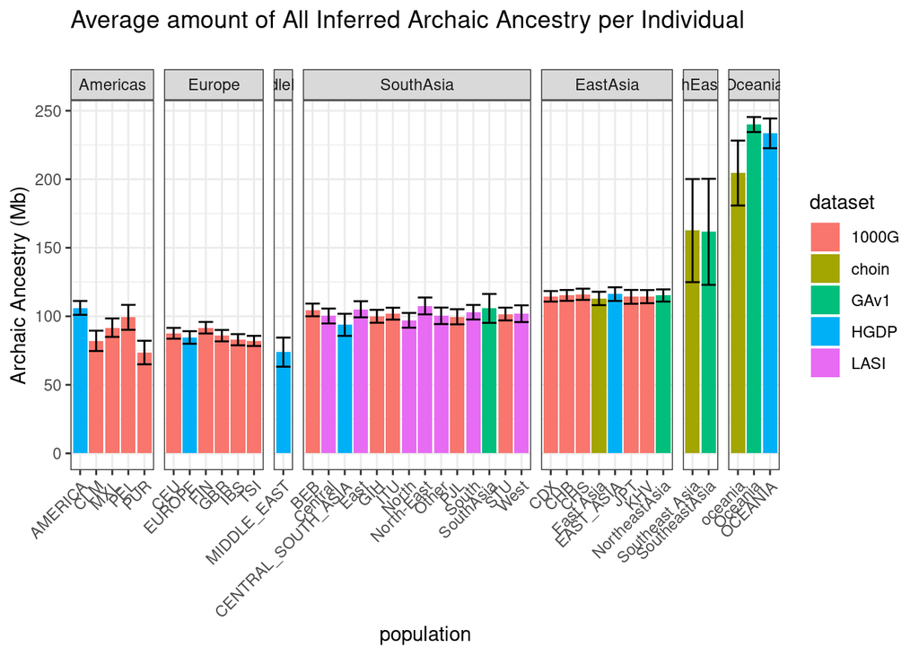

```r
p_all <- class1 %>%
  #rename choin oceania so there's no overlap
  mutate(population = ifelse(dataset == "choin" & Region == "Oceania", "oceania", as.character(population))) %>%
  group_by(population, dataset, Region, ID) %>%
  summarize(amount = sum(amount)) %>%
  ungroup() %>%
  group_by(population, dataset, Region) %>%
  summarize(avg = mean(amount) / 1000000, sd = sd(amount) / 1000000) %>%
  ggplot(aes(x = population, y = avg, fill = dataset)) +
    geom_bar(stat = "identity") +
    geom_errorbar(aes(ymin = avg - sd, ymax = avg + sd)) +
    theme_bw() +
    labs(title = "Average amount of All Inferred Archaic Ancestry per Individual\n", y = "Archaic Ancestry (Mb)") +
    theme(axis.text.x = element_text(angle = 45, hjust = 1, vjust = 1)) +
    facet_grid(. ~ Region, scales = "free", space = "free_x")
plot(p_all)
```

```r
p_ind <- class1 %>% group_by(population, class_1, dataset, Region, ID) %>%
  summarize(amount = sum(amount)) %>%
  ungroup() %>%
  group_by(population, class_1, dataset, Region) %>%
  summarize(avg = mean(amount) / 1000000, sd = sd(amount) / 1000000) %>%
  ggplot(aes(x = population, y = avg, fill = Region)) +
    geom_bar(stat = "identity") +
    geom_errorbar(aes(ymin = avg - sd, ymax = avg + sd)) +
    theme_bw() +
    labs(title = "Average amount of Ancestry per Individual\nClass 1: Most Likely", y = "Archaic Ancestry (Mb)") +
    theme(axis.text.x = element_text(angle = 45, hjust = 1, vjust = 1)) +
    facet_grid(class_1 ~ dataset, scales = "free", space = "free_x")
```

```
## 'Region'. You can override using the `.groups` argument.
```

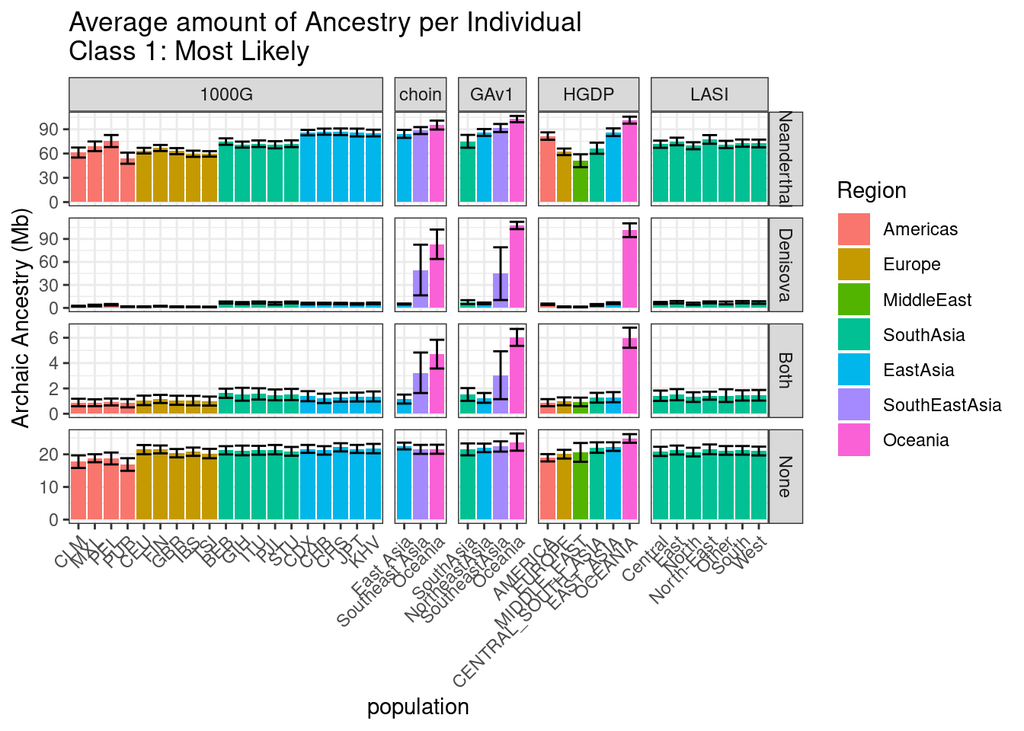

```r
plot(p_ind)
```

```r
p_ind_frac <- class1 %>% group_by(population, class_1, dataset, Region, ID) %>%
  summarize(amount = sum(amount)) %>%
  ungroup() %>%
  group_by(population, class_1, dataset, Region) %>%
  summarize(avg = mean(amount) / (2 * 2550757832) * 100, sd = sd(amount) / (2 * 2550757832) * 100) %>%
  ggplot(aes(x = population, y = avg, fill = Region)) +
    geom_bar(stat = "identity") +
    geom_errorbar(aes(ymin = avg - sd, ymax = avg + sd)) +
    theme_bw() +
    labs(title = "Average amount of Ancestry per Individual\nClass 1: Most Likely", y = "Archaic Ancestry (%)") +
    theme(axis.text.x = element_text(angle = 45, hjust = 1, vjust = 1)) +
    facet_grid(class_1 ~ dataset, scales = "free", space = "free_x")
```

```
## 'Region'. You can override using the `.groups` argument.
```

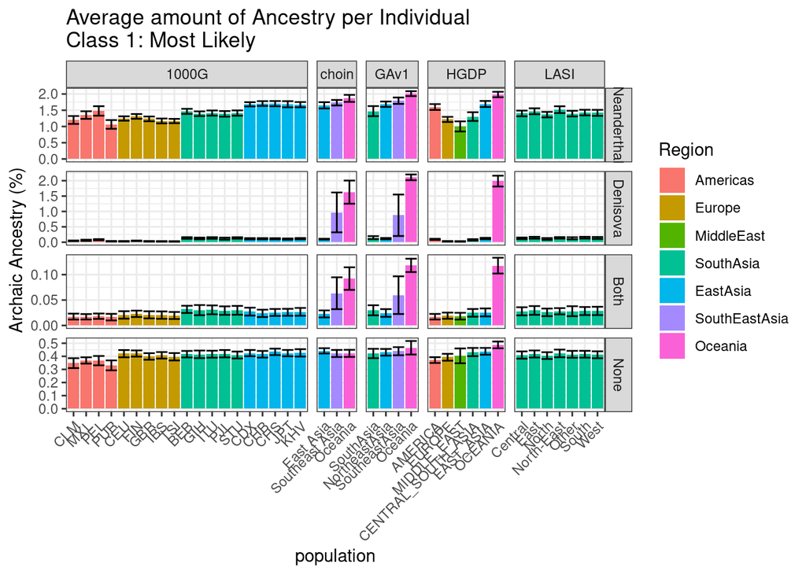

```r
plot(p_ind_frac)
```

```
## You can override using the `.groups` argument.
```

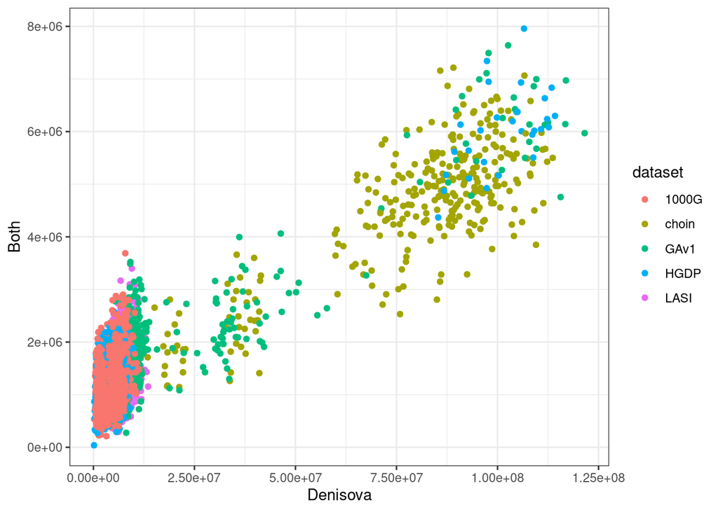

```r
class1 %>% group_by(ID, population, Region, dataset, class_1) %>%
  summarize(amount = sum(amount)) %>%
  pivot_wider(names_from = class_1, values_from = amount) %>%
  ggplot(aes(x = Denisova, y = Both, color = dataset)) +
    theme_bw() +
    geom_point()
```

```
## You can override using the `.groups` argument.
```

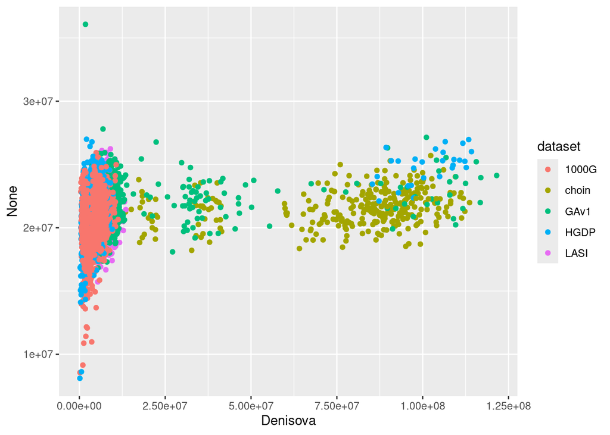

```r
class1 %>% group_by(ID, population, Region, dataset, class_1) %>%
  summarize(amount = sum(amount)) %>%
  pivot_wider(names_from = class_1, values_from = amount) %>%
  ggplot(aes(x = Denisova, y = None, color = dataset)) +
    geom_point()
```

```
## You can override using the `.groups` argument.
```

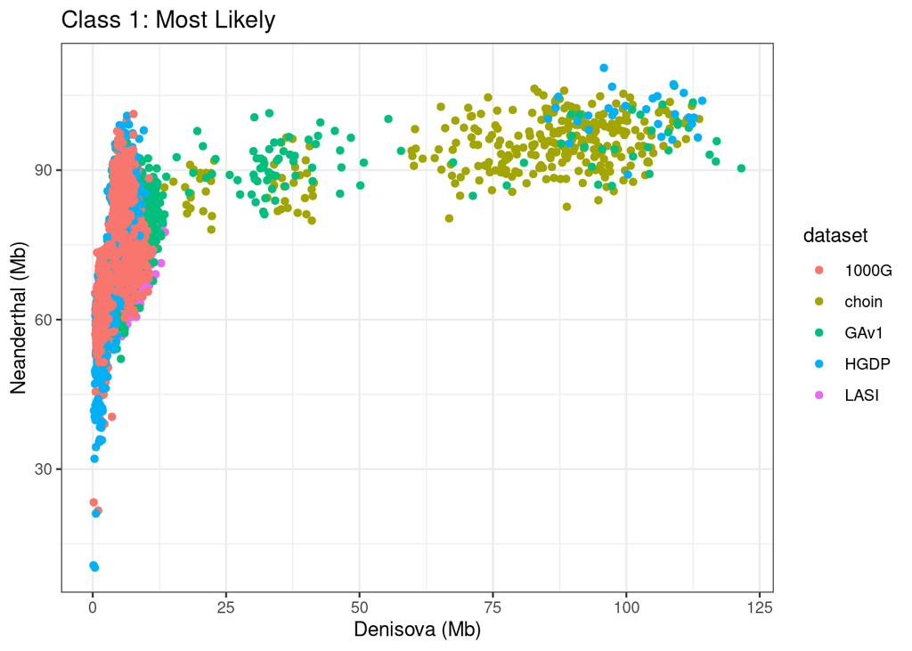

```r
class1 %>% group_by(ID, population, Region, dataset, class_1) %>%
  summarize(amount = sum(amount)) %>%
  pivot_wider(names_from = class_1, values_from = amount) %>%
  ggplot(aes(x = Denisova / 1000000, y = Neanderthal / 1000000, color = dataset)) +
  labs(title = "Class 1: Most Likely", x = "Denisova (Mb)", y = "Neanderthal (Mb)") +
    theme_bw() +
    geom_point()
```

```
## You can override using the `.groups` argument.
```

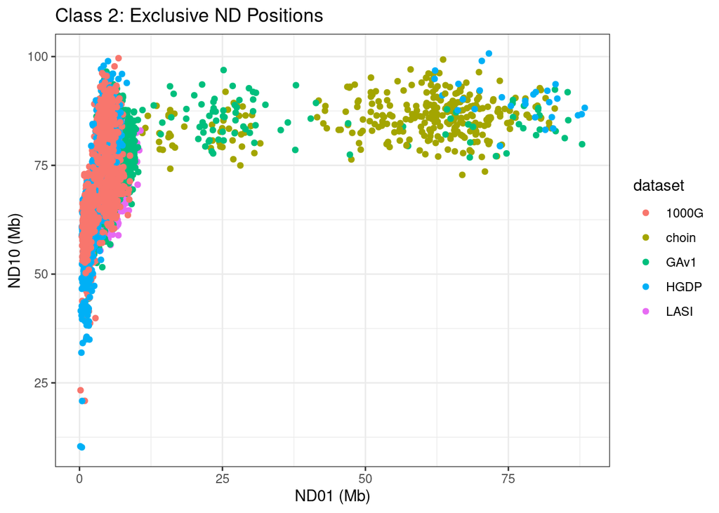

```r
class2 %>% group_by(ID, population, Region, dataset, class_2) %>%
  summarize(amount = sum(amount)) %>%
  pivot_wider(names_from = class_2, values_from = amount) %>%
  ggplot(aes(x = ND01 / 1000000, y = ND10 / 1000000, color = dataset)) +
    labs(title = "Class 2: Exclusive ND Positions", x = "ND01 (Mb)", y = "ND10 (Mb)") +
    theme_bw() +
    geom_point()
```

Additionally write out the merged metadata for later:

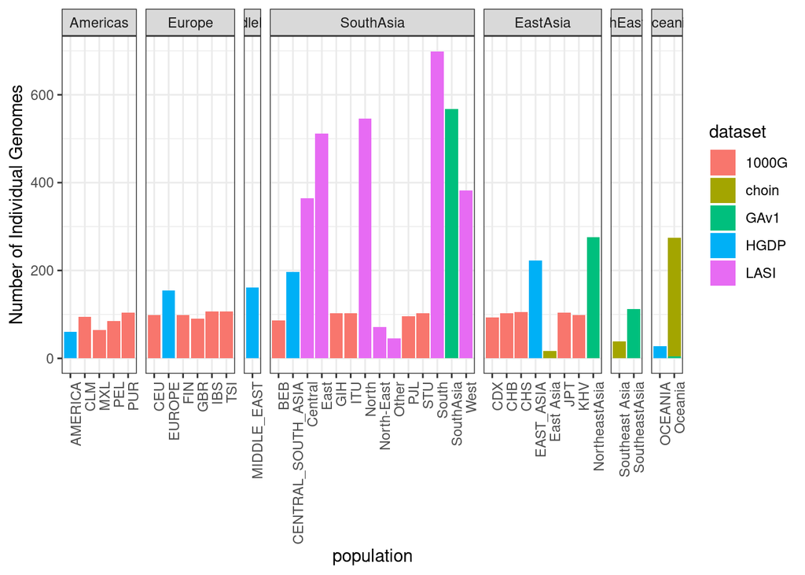

```r
class1 %>% select(ID, dataset, population, Region, population_specific, code) %>%
  unique() %>%
  write.table("data/combined_fragments/combined_metadata.txt", sep = "\t", quote = F, row.names = F)

class1$plot_easy <- ifelse(is.na(class1$population_specific), class1$Region, class1$population_specific)

class1 %>% select(ID, dataset, population, Region) %>%
  unique() %>%
  ggplot(aes(x = population, fill = dataset)) +
  geom_histogram(stat = "count") +
  theme_bw() +
  labs(y = "Number of Individual Genomes") +
  theme(axis.text.x = element_text(angle = 90, hjust = 1, vjust = 1)) +
  facet_grid(~Region, scales = "free", space = "free")
```

```r
class1 %>% select(ID, dataset, population, Region) %>%
  unique() %>%
  group_by(population, dataset) %>%
  summarize(n())
```

```
## # A tibble: 39 × 3
## # Groups:   population [38]
##    population dataset `n()`
##    <fct>      <chr>   <int>
##  1 AMERICA    HGDP       61
##  2 CLM        1000G      94
##  3 MXL        1000G      64
##  4 PEL        1000G      85
##  5 PUR        1000G     104
##  6 CEU        1000G      99
##  7 EUROPE     HGDP      155
##  8 FIN        1000G      99
##  9 GBR        1000G      91
## 10 IBS        1000G     107
## # ℹ 29 more rows
```

Repeat the analysis, but now classify fragments by class 2: exclusive ND snps

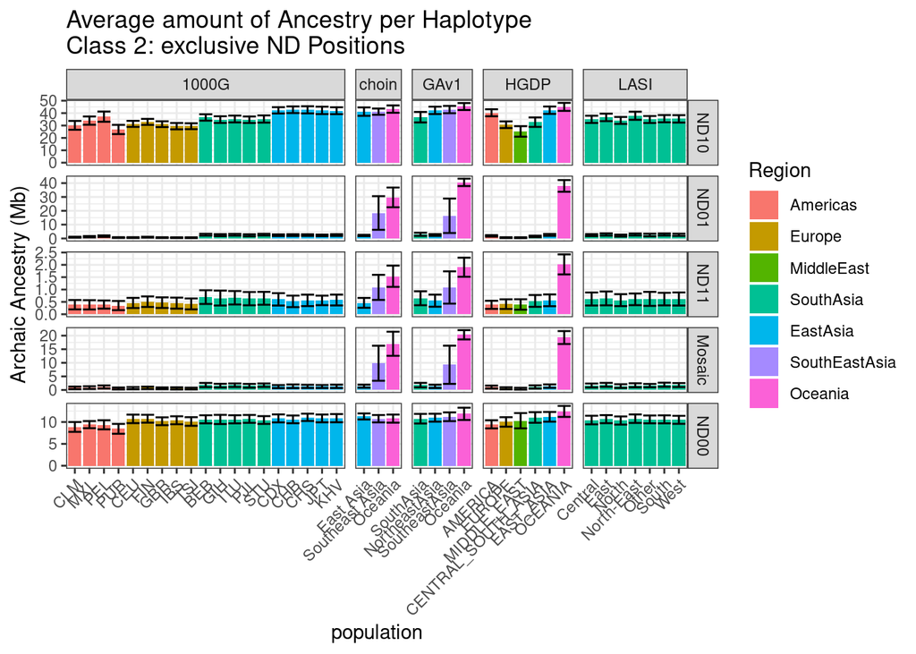

```r
# Ensure Region has a defined order
class2$Region <- factor(class2$Region, levels = c("Americas", "Europe", "MiddleEast", "SouthAsia", "EastAsia", "SouthEastAsia", "Oceania"))

# Arrange populations by Region and then convert to factor
pop_levels <- class2 %>%
  distinct(population, Region) %>%
  arrange(Region, population) %>%
  pull(population)
class2$population <- factor(class2$population, levels = pop_levels)

# finally order the classifications
class2$class_2 <- factor(class2$class_2, levels = c("ND10", "ND01", "ND11", "Mosaic", "ND00"), ordered = T)

p_hap2 <- class2 %>% group_by(population, class_2, dataset, Region) %>%
  summarize(avg = mean(amount) / 1000000, sd = sd(amount) / 1000000) %>%
  ggplot(aes(x = population, y = avg, fill = Region)) +
    geom_bar(stat = "identity") +
    geom_errorbar(aes(ymin = avg - sd, ymax = avg + sd)) +
    theme_bw() +
    labs(title = "Average amount of Ancestry per Haplotype\nClass 2: exclusive ND Positions", y = "Archaic Ancestry (Mb)") +
    theme(axis.text.x = element_text(angle = 45, hjust = 1, vjust = 1)) +
    facet_grid(class_2 ~ dataset, scales = "free", space = "free_x")
plot(p_hap2)
```

```r
p_ind2 <- class2 %>% group_by(population, class_2, dataset, Region, ID) %>%
  summarize(amount = sum(amount)) %>%
  ungroup() %>%
  group_by(population, class_2, dataset, Region) %>%
  summarize(avg = mean(amount) / 1000000, sd = sd(amount) / 1000000) %>%
  ggplot(aes(x = population, y = avg, fill = Region)) +
    geom_bar(stat = "identity") +
    geom_errorbar(aes(ymin = avg - sd, ymax = avg + sd)) +
    theme_bw() +
    labs(title = "Average amount of Ancestry per Individual\nClass 2: exclusive ND Positions", y = "Archaic Ancestry (Mb)") +
    theme(axis.text.x = element_text(angle = 45, hjust = 1, vjust = 1)) +
    facet_grid(class_2 ~ dataset, scales = "free", space = "free_x")
```

```
## 'Region'. You can override using the `.groups` argument.
```

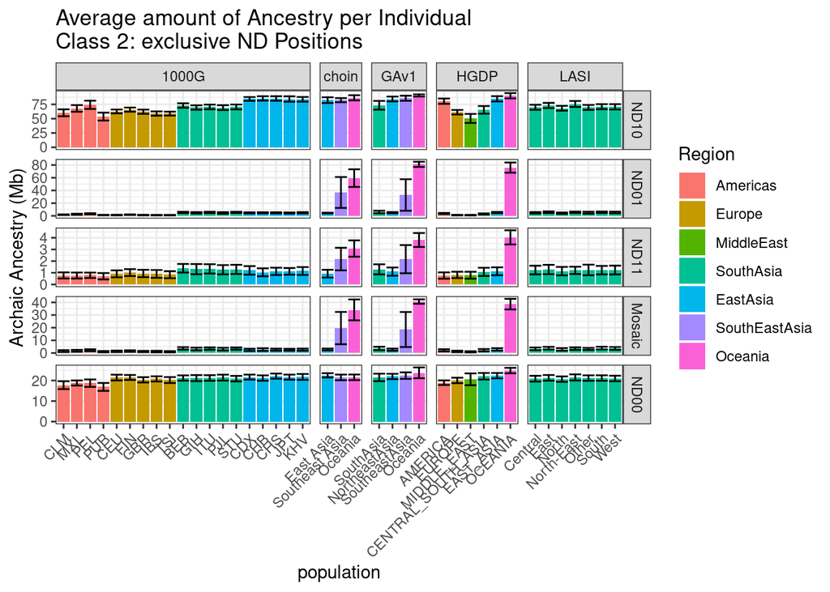

```r
plot(p_ind2)
```

```r
p_ind2_frac <- class2 %>% group_by(population, class_2, dataset, Region, ID) %>%
  summarize(amount = sum(amount)) %>%
  ungroup() %>%
  group_by(population, class_2, dataset, Region) %>%
  summarize(avg = mean(amount) / (2 * 2550757832) * 100, sd = sd(amount) / (2 * 2550757832) * 100) %>%
  ggplot(aes(x = population, y = avg, fill = Region)) +
    geom_bar(stat = "identity") +
    geom_errorbar(aes(ymin = avg - sd, ymax = avg + sd)) +
    theme_bw() +
    labs(title = "Average amount of Ancestry per Individual\nClass 2: exclusive ND Positions", y = "Archaic Ancestry (%)") +
    theme(axis.text.x = element_text(angle = 45, hjust = 1, vjust = 1)) +
    facet_grid(class_2 ~ dataset, scales = "free", space = "free_x")
```

```
## 'Region'. You can override using the `.groups` argument.
```

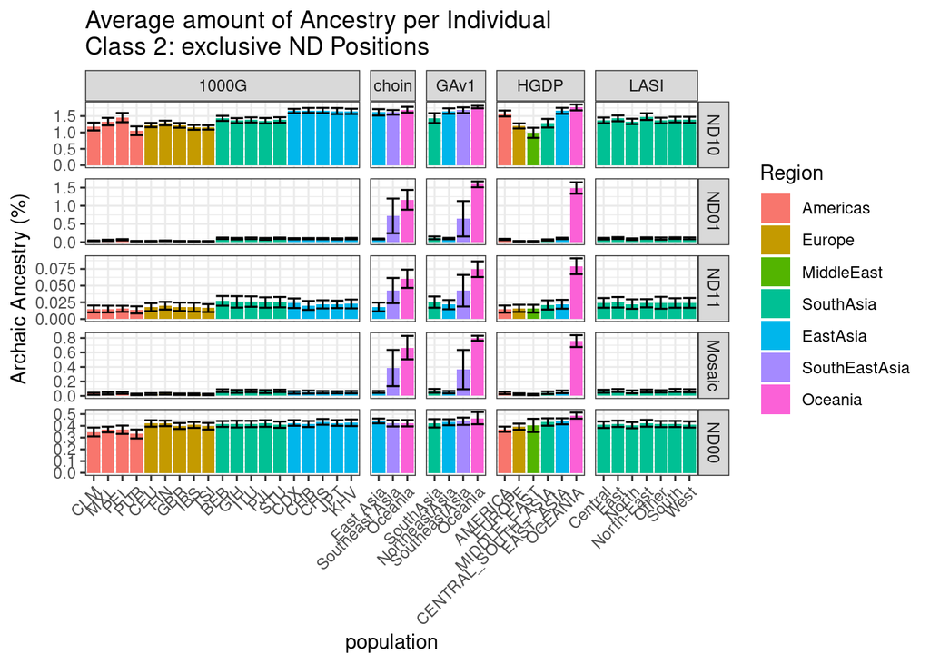

```r
plot(p_ind2_frac)
```

Lets focus on the populations with notable Denisovan ancestry

```r
# within oceania, I want to rename some of these populations
class1$population_specific <- ifelse(class1$dataset == "choin" & class1$Region == "Oceania", class1$code, class1$population_specific)

class2$population_specific <- ifelse(class2$dataset == "choin" & class2$Region == "Oceania", class2$code, class2$population_specific)

p_ind_den2 <- class2 %>% filter(Region %in% c("Oceania", "SouthEastAsia")) %>% group_by(population, class_2, population_specific, dataset, Region, ID) %>%
  summarize(amount = sum(amount)) %>%
  ungroup() %>%
  group_by(population, population_specific, class_2, dataset, Region) %>%
  summarize(avg = mean(amount) / 1000000, sd = sd(amount) / 1000000) %>%
  ggplot(aes(x = population_specific, y = avg, fill = Region)) +
    geom_bar(stat = "identity") +
    geom_errorbar(aes(ymin = avg - sd, ymax = avg + sd)) +
    theme_bw() +
    labs(title = "Average amount of Ancestry per Individual\nClass 2: exclusive ND Positions", y = "Archaic Ancestry (Mb)") +
    theme(axis.text.x = element_text(angle = 45, hjust = 1, vjust = 1)) +
    facet_grid(class_2 ~ dataset, scales = "free", space = "free_x")
```

```
## 'population_specific', 'dataset', 'Region'. You can override using the
## 'class_2', 'dataset'. You can override using the `.groups` argument.
```

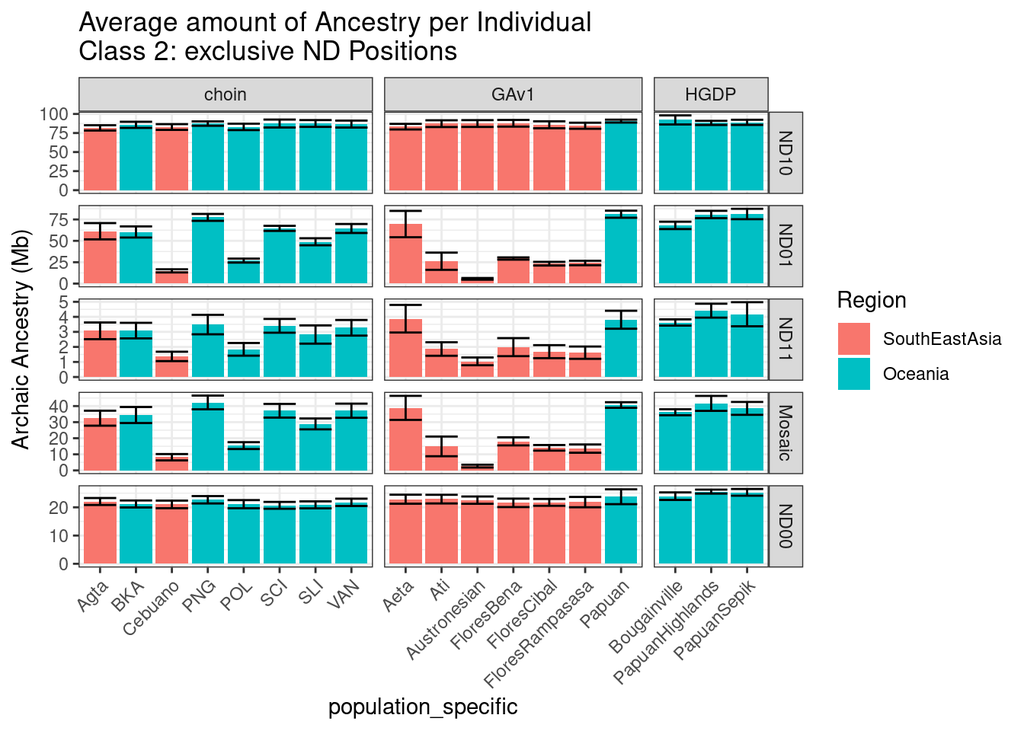

```r
plot(p_ind_den2)
```

```r
p_ind_den1 <- class1 %>% filter(Region %in% c("Oceania", "SouthEastAsia")) %>% group_by(population, class_1, population_specific, dataset, Region, ID) %>%
  summarize(amount = sum(amount)) %>%
  ungroup() %>%
  group_by(population, population_specific, class_1, dataset, Region) %>%
  summarize(avg = mean(amount) / 1000000, sd = sd(amount) / 1000000) %>%
  ggplot(aes(x = population_specific, y = avg, fill = Region)) +
    geom_bar(stat = "identity") +
    geom_errorbar(aes(ymin = avg - sd, ymax = avg + sd)) +
    theme_bw() +
    labs(title = "Average amount of Ancestry per Individual\nClass 1: most likely", y = "Archaic Ancestry (Mb)") +
    theme(axis.text.x = element_text(angle = 45, hjust = 1, vjust = 1)) +
    facet_grid(class_1 ~ dataset, scales = "free", space = "free_x")
```

```
## 'population_specific', 'dataset', 'Region'. You can override using the
## 'class_1', 'dataset'. You can override using the `.groups` argument.
```

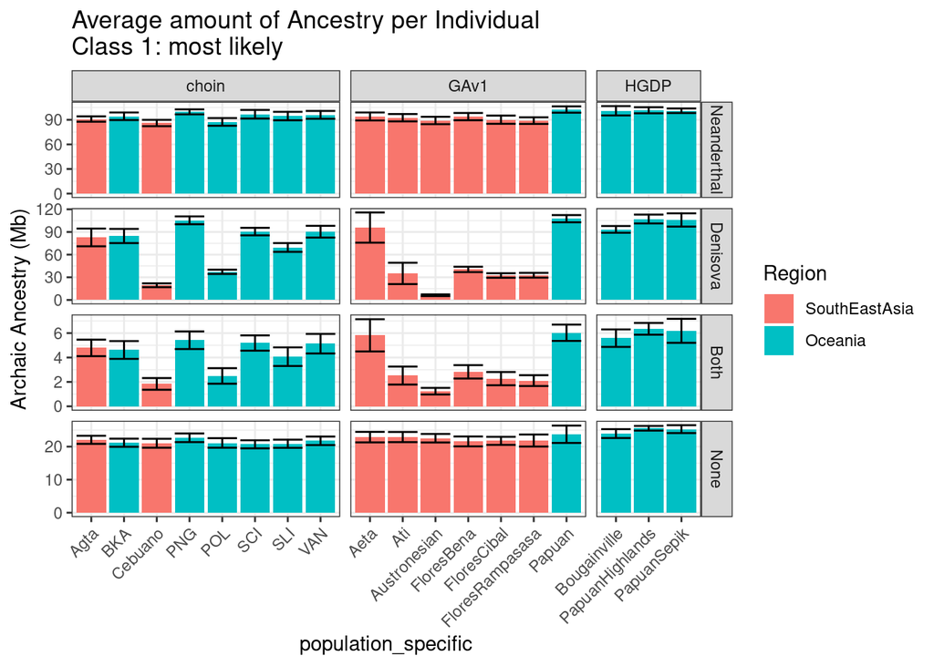

```r
plot(p_ind_den1)
```

Focus only on Denisovan ancestry

```r
class1$population_specific <- ifelse(class1$dataset %in% c("1000G", "LASI"), as.character(class1$population), class1$population_specific)

class1$plot_easy <- ifelse(class1$dataset %in% c("GAv1", "1000G", "HGDP") & !class1$Region %in% c("Oceania", "SouthEastAsia"), as.character(class1$Region), class1$population_specific)

den_1 <- class1 %>% filter(class_1 == "Denisova", Region %in% c( "SouthEastAsia", "Oceania", "EastAsia")) %>% group_by(population, class_1, population_specific, dataset, Region, ID) %>%
  summarize(amount = sum(amount)) %>%
  ungroup() %>%
  group_by(population, population_specific, class_1, dataset, Region) %>%
  summarize(avg = mean(amount) / 1000000, sd = sd(amount) / 1000000)
```

```
## 'population_specific', 'dataset', 'Region'. You can override using the
## 'class_1', 'dataset'. You can override using the `.groups` argument.
```

```r
den_2 <- class2 %>% filter(class_2 == "ND01", Region %in% c( "SouthEastAsia", "Oceania", "EastAsia")) %>% group_by(population, class_2, population_specific, dataset, Region, ID) %>%
  summarize(amount = sum(amount)) %>%
  ungroup() %>%
  group_by(population, population_specific, class_2, dataset, Region) %>%
  summarize(avg_2 = mean(amount) / 1000000, sd_2 = sd(amount) / 1000000)
```

```
## 'population_specific', 'dataset', 'Region'. You can override using the
## 'class_2', 'dataset'. You can override using the `.groups` argument.
```

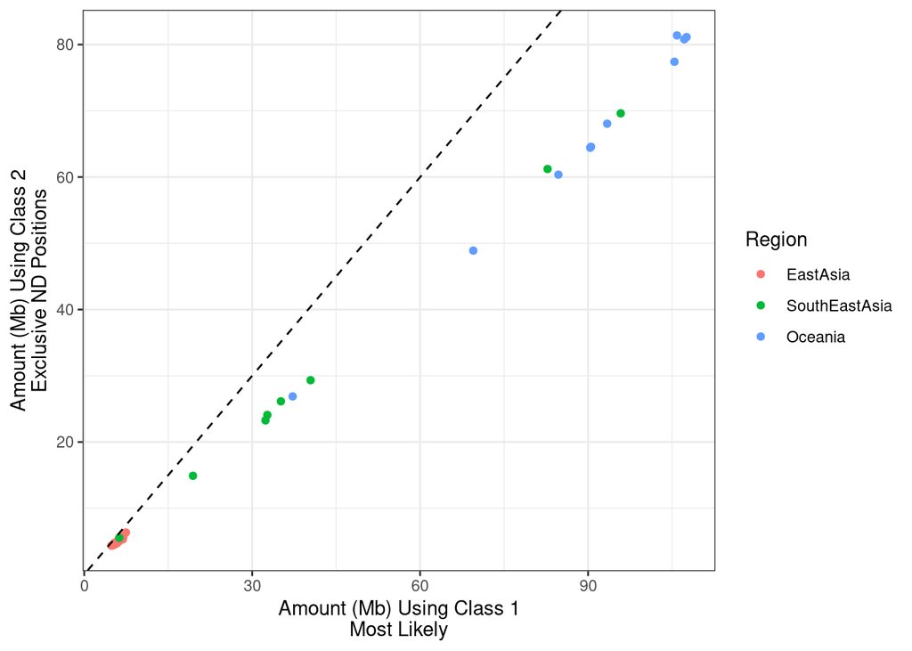

```r
den <- merge(den_1, den_2)

p_ind_corr <- den %>% ggplot(aes(x = avg, y = avg_2, color = Region)) +
  geom_point() +
  geom_abline(slope = 1, intercept = 0, linetype = "dashed") +
  theme_bw() +
  labs(x = "Amount (Mb) Using Class 1\nMost Likely", y = "Amount (Mb) Using Class 2\nExclusive ND Positions")
plot(p_ind_corr)
```

```r
p_ind_den1 <- class1 %>% filter(class_1 == "Denisova", Region %in% c( "SouthEastAsia", "Oceania", "EastAsia", "SouthAsia")) %>% group_by(class_1, plot_easy, dataset, Region, ID) %>%
  summarize(amount = sum(amount)) %>%
  ungroup() %>%
  group_by(plot_easy, class_1, dataset, Region) %>%
  summarize(avg = mean(amount) / 1000000, sd = sd(amount) / 1000000) %>%
  ggplot(aes(x = plot_easy, y = avg, fill = Region)) +
    geom_bar(stat = "identity") +
    geom_errorbar(aes(ymin = avg - sd, ymax = avg + sd)) +
    theme_bw() +
    labs(title = "Average amount of Ancestry per Individual\nClass 1: most likely", y = "Archaic Ancestry (Mb)") +
    theme(axis.text.x = element_text(angle = 45, hjust = 1, vjust = 1)) +
    facet_grid(class_1 ~ dataset, scales = "free", space = "free_x")
```

```
## 'Region'. You can override using the `.groups` argument.
```

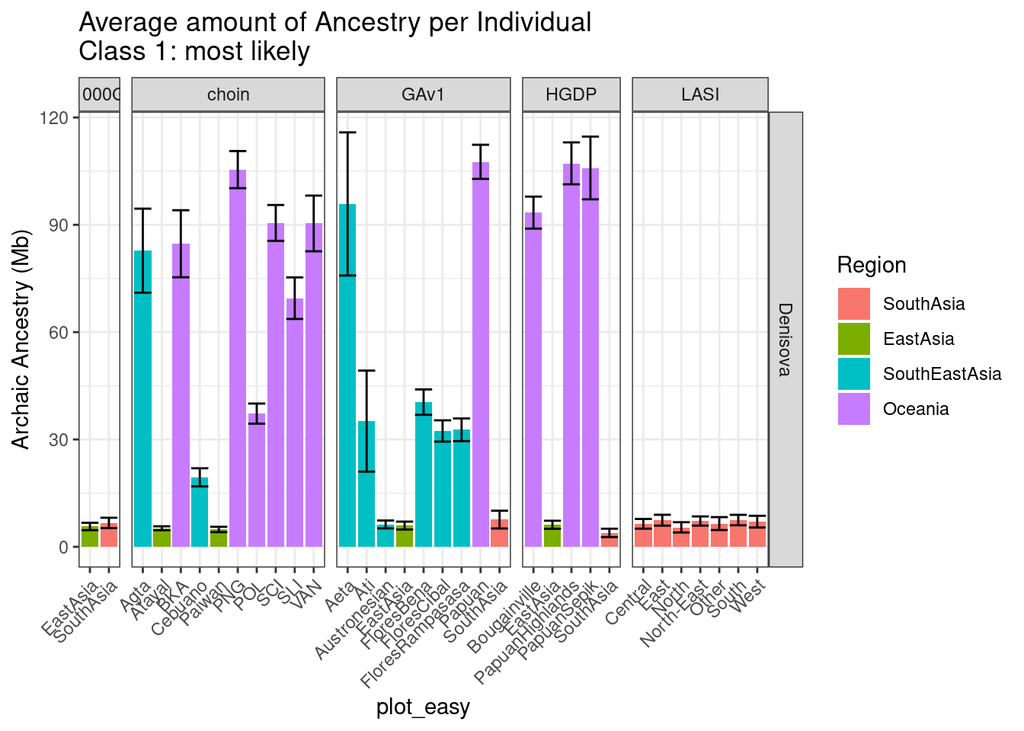

```r
plot(p_ind_den1)
```

```r
pdf("/global/scratch/p2p3/pl1_moorjani/sarahj32/denisova_dating/plots/ancestry/Den_SEA_OCE_EAS.pdf", height = 4, width = 8.5)
plot(p_ind_den1)
dev.off()
```

Finally compare the amount of “unclassified” if we require that there are 10 callable archaic positions in each fragment

```r
class1_call <- data.frame()
for (dataset in c("GAv1", "LASI", "1000G", "choin")){
  dat_class1_call <- read.table(paste0("summary_dat/hmmix/", dataset, "_class1_call10_perIndiv.txt"), header =T, sep = "\t")
  dat_class1_call$dataset <- dataset
  class1_call <- rbindlist(list(class1_call, dat_class1_call), use.names = T, fill = T)
}
#class1_call$population <- ifelse(is.na(class1_call$population), class1_call$region.y, class1_call$population)

class1_call <- label_region(class1_call)

# Ensure Region has a defined order
class1_call$Region <- factor(class1_call$Region, levels = c("Americas", "Europe", "MiddleEast", "SouthAsia", "EastAsia", "SouthEastAsia", "Oceania"))

# Arrange populations by Region and then convert to factor
pop_levels <- class1_call %>%
  distinct(population, Region) %>%
  arrange(Region, population) %>%
  pull(population)
class1_call$population <- factor(class1_call$population, levels = pop_levels)

# finally order the classifications
class1_call$class_1 <- factor(class1_call$class_1, levels = c("Neanderthal", "Denisova", "Both", "None"), ordered = T)

p_ind_call <- class1_call %>% group_by(population, class_1, dataset, Region, ID) %>%
  summarize(amount = sum(amount)) %>%
  ungroup() %>%
  group_by(population, class_1, dataset, Region) %>%
  summarize(avg = mean(amount) / 1000000, sd = sd(amount) / 1000000) %>%
  ggplot(aes(x = population, y = avg, fill = Region)) +
    geom_bar(stat = "identity") +
    geom_errorbar(aes(ymin = avg - sd, ymax = avg + sd)) +
    theme_bw() +
    labs(title = "Average amount of Ancestry per Individual\nClass 1: Most Likely", y = "Archaic Ancestry (Mb)") +
    theme(axis.text.x = element_text(angle = 45, hjust = 1, vjust = 1)) +
    facet_grid(class_1 ~ dataset, scales = "free", space = "free_x")
```

```
## 'Region'. You can override using the `.groups` argument.
```

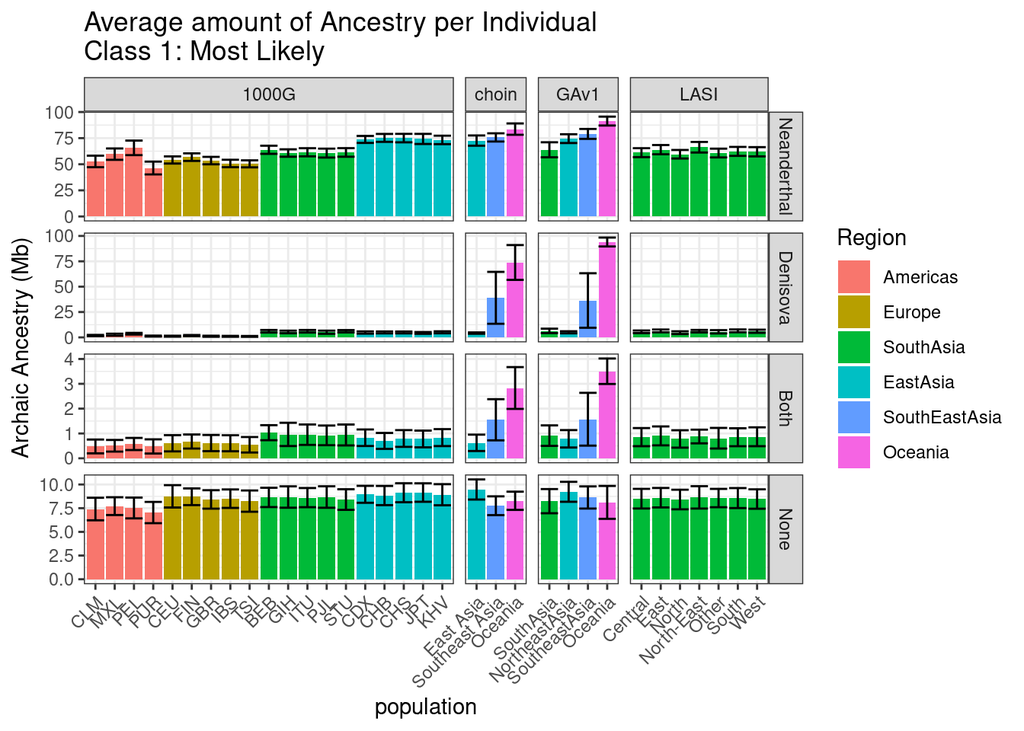

```r
plot(p_ind_call)
```